# The Capstone Project

WaleAOT

4/8/2022

```r
#bring in the datasets
orders <- read_csv("orders.csv")
people <- read_csv("people.csv")
returns <- read_csv("returns.csv")
```

Question 1. a) What are the three countries that generated the highest total profit for Global Superstore in 2014? b) For each of these three countries, find the three products with the highest total profit. Specifically, what are the products’ names and the total profit for each product?

```r
orders <- orders %>% mutate(Year = str_sub(Ship_Date,-4,-1))


highest_country <- orders %>%
                filter(Year == "2014") %>%
            #extract profits by country
                   group_by(Country,Year)%>%
   summarise(Total_profit = sum(round(Profit,digits = 4)))
highest_country <- highest_country %>%
                  as.data.frame() %>%
#rearrange profit from highest to lowest(since we are concerned with highest                            values)
                    arrange(desc(Total_profit))
View(highest_country)
```

```r
#focusing on the top 20 countries for convenience...
  highest_country_top_20 <- highest_country[c(1:30),]

#Let ggplot order the plot by total_profit
  highest_country_top_20$Country <- factor(highest_country_top_20$Country,
                                  levels =   highest_country_top_20$Country[order(highest_country_top_20$Total_profit)])
```

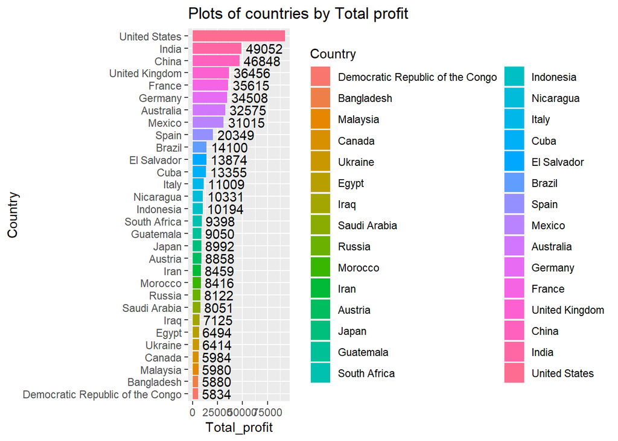

```r
#Visualization proper

ggplot(data = highest_country_top_20, aes(x= Total_profit, y=Country, fill= Country)) +   geom_bar(stat="identity") + ggtitle(label = "Plots of countries by Total profit")+ geom_text(aes(label = round(Total_profit)),hjust = -0.12)
```

From the plot, United States of America, China and India are the top 3 countries with the highest profit in the year 2014.

Question 1b For each of these three countries, find the three products with the highest total profit. Specifically, what are the products’ names and the total profit for each product?

```r
# Getting the products for the top 3 countries
#capture product name and profit for the 3 countries

Top_Country <- orders %>%
                select(Country, Profit,Product_Name, Year) %>%
                filter(Year == "2014" & Country %in%  c("United States",  "India" , "China"))
head(Top_Country)
```

| Country | Profit | Product_Name | Year |
| --- | --- | --- | --- |
| United States | 1906.4850 | Fellowes PB500 Electric Punch Plastic Comb Binding Machine with Manual Bind | 2014 |
| United States | 517.4793 | Logitech diNovo Edge Keyboard | 2014 |
| United States | -3839.9904 | Cubify CubeX 3D Printer Triple Head Print | 2014 |
| India | 632.5200 | Motorola Smart Phone, with Caller ID | 2014 |
| India | 2097.0300 | Sauder Classic Bookcase, Traditional | 2014 |
| China | 110.3400 | Novimex Executive Leather Armchair, Red | 2014 |

```r
#Get the data per country
#for USA
Top_Country_US <- Top_Country %>%
                filter( Country == "United States") %>%
                group_by(Product_Name) %>%
                summarise(Total_profit = sum(Profit))

#Convert the tibble to a dataframe, so we can rank Total_profit by desc.

Top_Country_US_df <- Top_Country_US %>%
                      as.data.frame() %>%
                      arrange(desc(Total_profit))

head(Top_Country_US_df)
```

|  | Product_Name | Total_profit |
| --- | --- | --- |
| 1 | Canon imageCLASS 2200 Advanced Copier | 15679.955 |
| 2 | Hewlett Packard LaserJet 3310 Copier | 3623.940 |
| 3 | GBC DocuBind TL300 Electric Binding System | 1910.589 |
| 4 | Fellowes PB300 Plastic Comb Binding Machine | 1753.715 |
| 5 | Canon Image Class D660 Copier | 1691.972 |
| 6 | Canon Imageclass D680 Copier / Fax | 1679.976 |

```r
#For China
Top_Country_China <- Top_Country %>%
                filter( Country == "China") %>%
                group_by(Product_Name) %>%
                summarise(Total_profit= sum(Profit))

#Convert the tibble to a dataframe, so we can rank.

Top_Country_china_df <- Top_Country_China %>%
                      as.data.frame() %>%
                      arrange(desc(Total_profit))

head(Top_Country_china_df,3)
```

|  | Product_Name | Total_profit |
| --- | --- | --- |
| 1 | Sauder Classic Bookcase, Metal | 1463.07 |
| 2 | Bush Classic Bookcase, Mobile | 1220.52 |
| 3 | HP Copy Machine, Color | 1196.13 |

```r
Top_Country_India <- Top_Country %>%
                filter( Country == "India") %>%
                group_by(Product_Name) %>%
                summarise(Total_profit= sum(Profit))

#Convert the tibble to a dataframe, so we can rank.

Top_Country_India_df <- Top_Country_India %>%
                      as.data.frame() %>%
                      arrange(desc(Total_profit))

head(Top_Country_India_df,3)
```

|  | Product_Name | Total_profit |
| --- | --- | --- |
| 1 | Sauder Classic Bookcase, Traditional | 2419.65 |
| 2 | Cisco Smart Phone, with Caller ID | 1609.38 |
| 3 | Hamilton Beach Refrigerator, Red | 1440.24 |

Question 2 Identify the 3 subcategories with the highest average shipping cost in the United States.

```r
US_avg_shipping_by_category <- orders %>%
                                select(Country, `Shipping Cost`, Sub_Category)%>%
                                filter(Country == "United States")%>%
                                group_by(Sub_Category) %>%
                              summarise(cost =mean(`Shipping Cost`))


US_avg_ship_bycat <-   US_avg_shipping_by_category %>%
                         data.frame()%>%
                        arrange(desc(cost))
head(US_avg_ship_bycat)
```

|  | Sub_Category | cost |
| --- | --- | --- |
| 1 | Copiers | 165.28868 |
| 2 | Machines | 132.24539 |
| 3 | Tables | 69.95000 |
| 4 | Chairs | 58.43276 |
| 5 | Bookcases | 51.23434 |
| 6 | Phones | 41.01587 |

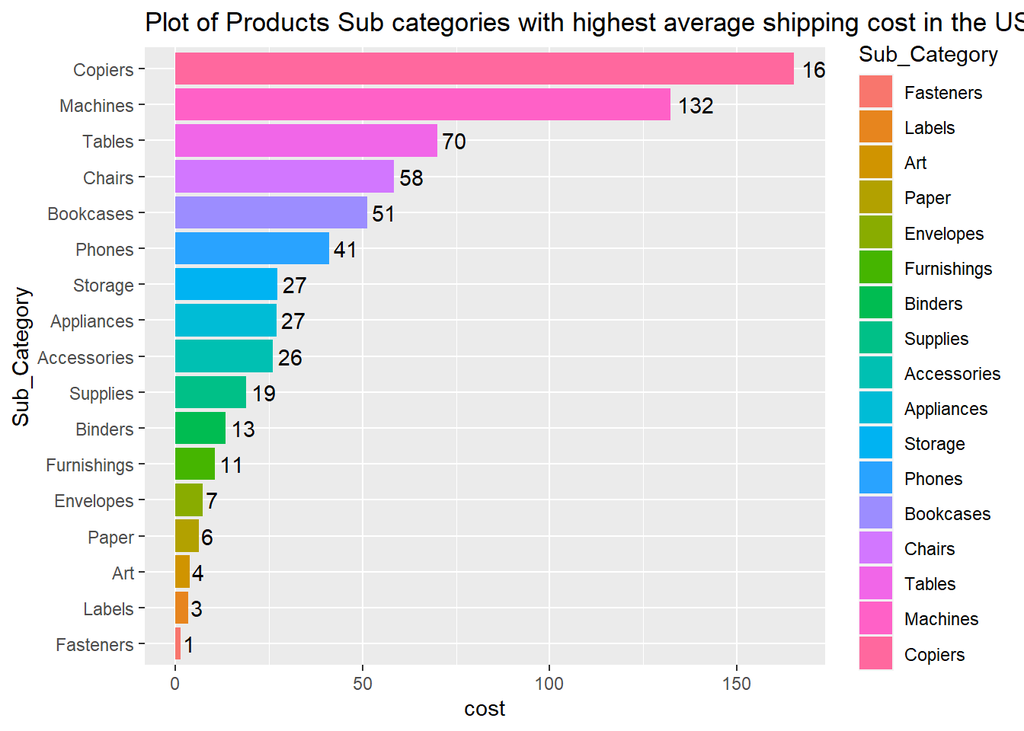

```r
#Let's visualize
US_avg_ship_bycat$Sub_Category <- factor(US_avg_ship_bycat$Sub_Category, levels= US_avg_ship_bycat$Sub_Category[order(US_avg_ship_bycat$cost)])

ggplot(data = US_avg_ship_bycat, aes(y=Sub_Category, x= cost, fill = Sub_Category)) + geom_bar(stat = "identity") + ggtitle(label = "Plot of Products Sub categories with highest average shipping cost in the US") + geom_text(aes(label = round(cost)),hjust = -0.2)
```

Question 3. a) Assess Nigeria’s profitability (i.e., total profit) for 2014. How does it compare to other African countries?

2. What factors might be responsible for Nigeria’s poor performance? You might want to investigate shipping costs and the average discount as potential root causes.

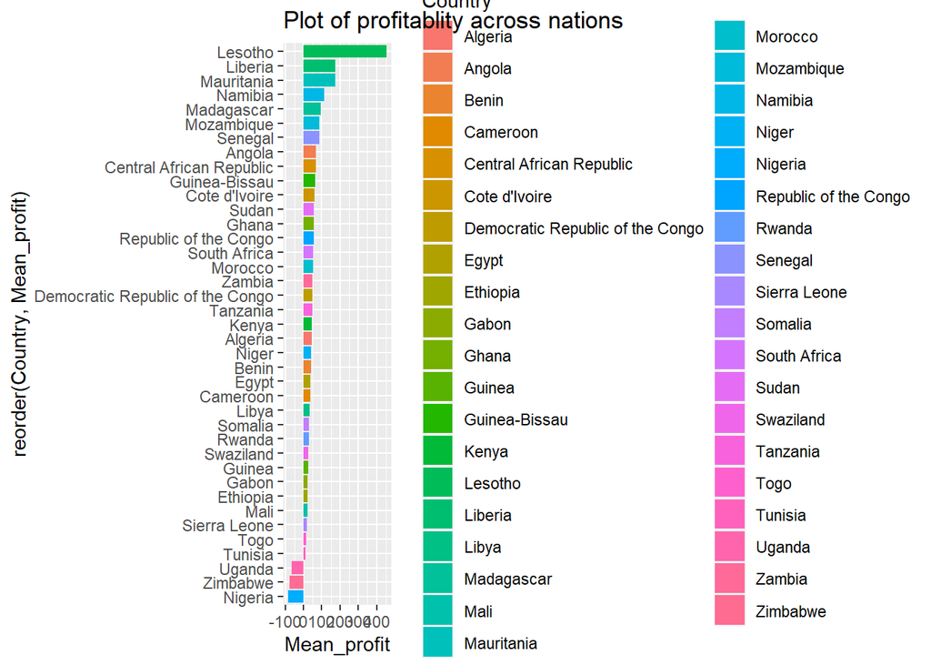

```r
naija_vs_Africa <- orders %>%
          select(Region, Country, Profit, Discount,Year) %>%
          filter(Region == "Africa" & Year =="2014")

naija_profit <- naija_vs_Africa %>% group_by(Country) %>% summarise(Mean_profit = mean(Profit))

naija_vs_Africa <- naija_vs_Africa %>% as.data.frame()%>% arrange(desc(Profit))

#Get the plot

ggplot(data = naija_profit, aes(y= reorder(Country, Mean_profit),x = Mean_profit, fill = Country)) + geom_bar(stat= "identity")+ ggtitle(label = "Plot of profitablity across nations")
```

```r
  geom_text(aes(label = round(Mean_profit)),hjust = -0.2)
```

```
## mapping: label = ~round(Mean_profit)
## geom_text: parse = FALSE, check_overlap = FALSE, na.rm = FALSE
## stat_identity: na.rm = FALSE
## position_identity
```

Interpretation: In Africa, on the average, Nigeria is the least profitable country.

This may be due to a lot of factors.

Nigeria, Uganda and Zimbabwe should consider tuning down on the discount. They are the only countries with the highest discounts and accounting for loss.

## possible Factors

Nigeria and Uganda and Zimbabwe should consider cutting down on discounts. They are the only with the highest discount and they are are the bottom of the profit table.

```r
possible_fac <- naija_vs_Africa %>%
        #arrange(desc(Discount)) %>%
  group_by(Country) %>% summarise(Mean_Discount = mean(Discount))

possible_fac <- possible_fac %>% arrange(desc(Mean_Discount))
possible_fac
```

| Country | Mean_Discount |
| --- | --- |
| Nigeria | 0.70000000 |
| Uganda | 0.70000000 |
| Zimbabwe | 0.70000000 |
| Tanzania | 0.01967213 |
| Algeria | 0.00000000 |
| Angola | 0.00000000 |
| Benin | 0.00000000 |
| Cameroon | 0.00000000 |
| Central African Republic | 0.00000000 |
| Cote d'Ivoire | 0.00000000 |

[output cut: 29 more lines]

Question 4. a) Identify the product subcategory that is the least profitable in Southeast Asia. Note: For this question, assume that Southeast Asia comprises Cambodia, Indonesia, Malaysia, Myanmar (Burma), the Philippines, Singapore, Thailand, and Vietnam. b) Is there a specific country in Southeast Asia where Global Superstore should stop offering the subcategory identified in 4a?

```r
asia_list <- orders %>% select (Region, Country, Sub_Category, `Shipping Cost`, Profit) %>%
  filter(Region == "Southeast Asia" )

asia_least_profitable <- asia_list %>% as.data.frame() %>%
                    arrange(desc(Profit))

tail(asia_least_profitable,10)
```

|  | Region | Country | Sub_Category | Shipping Cost | Profit |
| --- | --- | --- | --- | --- | --- |
| 3120 | Southeast Asia | Indonesia | Tables | 110.58 | -646.0974 |
| 3121 | Southeast Asia | Indonesia | Tables | 86.74 | -650.2734 |
| 3122 | Southeast Asia | Vietnam | Accessories | 120.49 | -692.9388 |
| 3123 | Southeast Asia | Indonesia | Tables | 39.89 | -708.5673 |
| 3124 | Southeast Asia | Thailand | Bookcases | 141.65 | -813.6144 |
| 3125 | Southeast Asia | Indonesia | Tables | 127.59 | -878.7684 |
| 3126 | Southeast Asia | Indonesia | Tables | 191.26 | -916.0443 |
| 3127 | Southeast Asia | Philippines | Tables | 163.02 | -976.5000 |
| 3128 | Southeast Asia | Thailand | Tables | 86.86 | -1195.2387 |
| 3129 | Southeast Asia | Thailand | Tables | 225.02 | -1294.3503 |

The least profitable product category are Tables, Bookcases and Accessories.

```r
stop_asia <- asia_least_profitable %>%
                filter(Sub_Category == "Tables")%>%
               group_by(Country) %>% summarise(Avg_Profit = sum(Profit))

stop_asia
```

| Country | Avg_Profit |
| --- | --- |
| Cambodia | 1361.790 |
| Indonesia | -10680.275 |
| Myanmar (Burma) | -1602.785 |
| Philippines | -3150.672 |
| Singapore | 164.400 |
| Thailand | -3187.896 |
| Vietnam | -1522.867 |

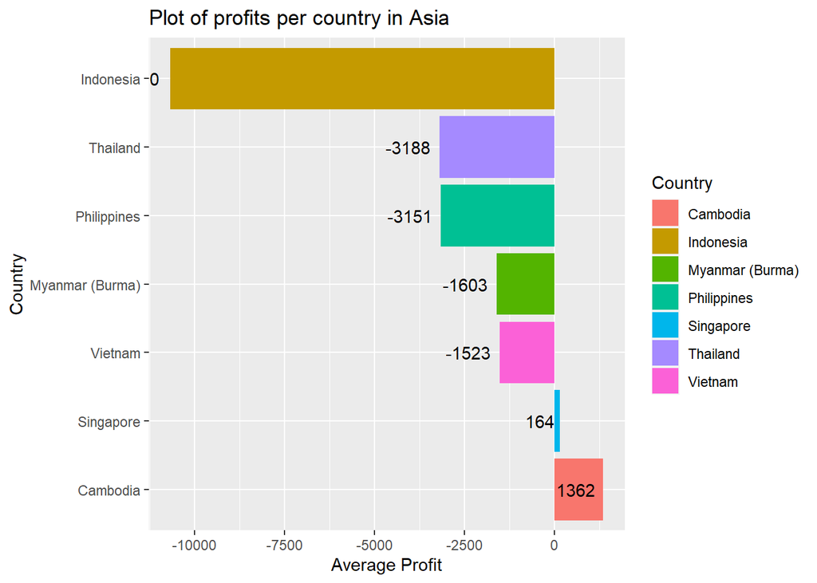

```r
ggplot(data = stop_asia , aes(y= reorder(Country,-Avg_Profit), x = Avg_Profit, fill = Country)) + geom_bar(stat= "identity")+ ggtitle(label = "Plot of profits per country in Asia")+
  geom_text(aes(label = round(Avg_Profit)),hjust = 1.2) + labs(x = "Average Profit", y = "Country")
```

## Yes! Indonesia.

Question 5. a) Which city is the least profitable (in terms of average profit) in the United States? For this analysis, discard the cities with less than 10 Orders. b) Why is this city’s average profit so low?

```r
city_usa <- orders %>%
            filter(Country == "United States") %>%
            select(City, Quantity, Profit)


#least_usa_city <- city_usa %>% filter( Quantity > 9 & City == "New York City")

 least_usa_city <- city_usa %>% filter( Quantity > 9 )%>%
                    group_by(City)%>%
                    summarise(Total_Quantity = sum(Quantity),Avg_profit =   mean(Profit),  Total_pro = sum(Profit))

#View(least_usa_city)

least_usa_city <- least_usa_city %>% as.data.frame() %>%                  arrange(desc(Avg_profit))
tail(least_usa_city,10)
```

|  | City | Total_Quantity | Avg_profit | Total_pro |
| --- | --- | --- | --- | --- |
| 65 | Huntsville | 14 | -22.68420 | -22.6842 |
| 66 | Scottsdale | 10 | -23.71600 | -23.7160 |
| 67 | Redmond | 10 | -25.05600 | -25.0560 |
| 68 | Tucson | 24 | -27.76600 | -55.5320 |
| 69 | Houston | 53 | -33.74620 | -168.7310 |
| 70 | Buffalo | 10 | -50.09800 | -50.0980 |
| 71 | Philadelphia | 126 | -59.02165 | -649.2382 |
| 72 | Charlotte | 33 | -109.70350 | -329.1105 |
| 73 | Toledo | 13 | -116.84400 | -116.8440 |
| 74 | Concord | 13 | -1862.31240 | -1862.3124 |

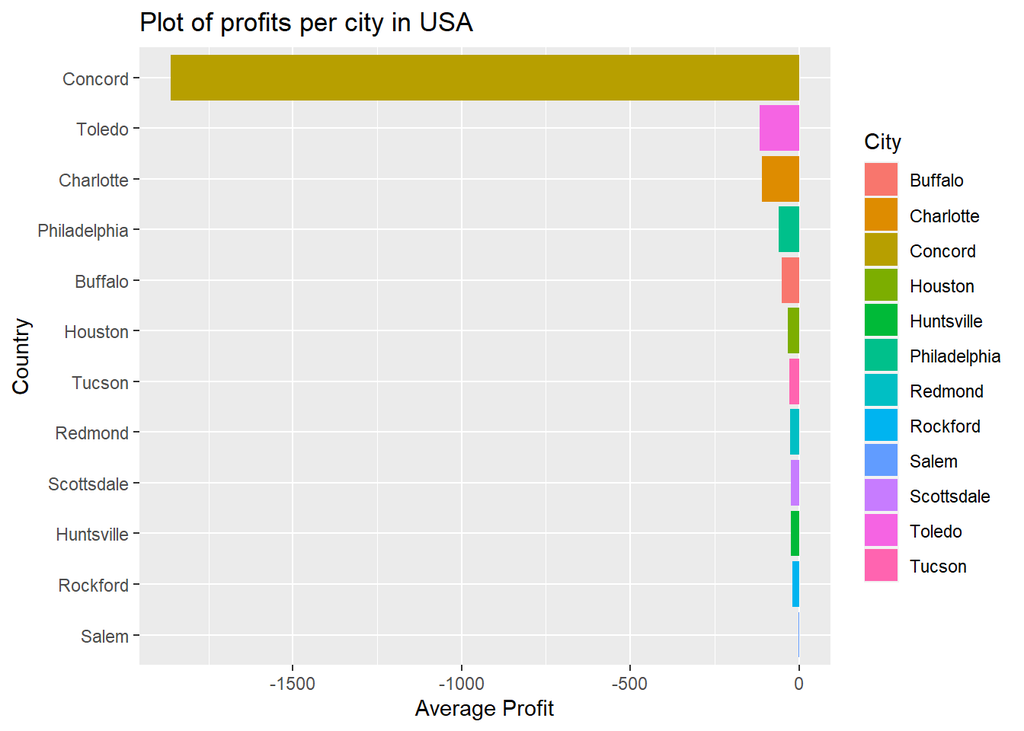

```r
#get the plot of the negative average profits.
least_usa_city_nve <- least_usa_city %>% filter( Avg_profit < 0)

 ggplot(data = least_usa_city_nve, aes( y = reorder(City, -Avg_profit), x = Avg_profit, fill = City)) + geom_bar(stat ="identity") + ggtitle(label = "Plot of profits per city in USA") +  labs(x = "Average Profit", y = "Country")
```

Concord is the least profitable city in the United States with quantity > 9.

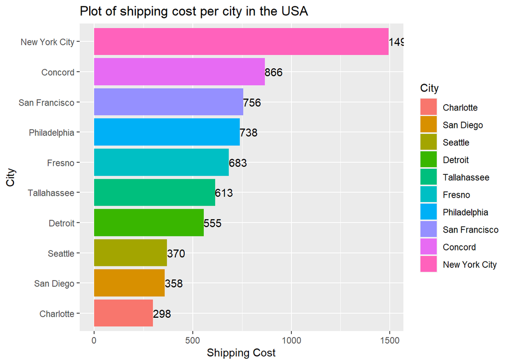

```r
concord_reason <- orders %>%
            filter(Country == "United States"  & Quantity >9) %>%
            select(City, Quantity, Profit, `Shipping Cost`, Discount)%>% group_by(City) %>% summarise(Quantity = sum(Quantity),Profit = mean(Profit),`Shipping Cost` = sum(`Shipping Cost`), Discount =sum(Discount))

concord_reason <- concord_reason %>% as.data.frame()%>% arrange(desc(`Shipping Cost`))

concord_reason_20 <- concord_reason[c(1:10),]

concord_reason_20$City  <- factor(concord_reason_20$City,                             levels = concord_reason_20$City[order(concord_reason_20$`Shipping Cost`)])


ggplot(data = concord_reason_20, aes( y = City, x = `Shipping Cost`, fill = City)) + geom_bar(stat ="identity") + ggtitle(label = "Plot of shipping cost per city in the USA")+
  geom_text(aes(label = round(`Shipping Cost`)),hjust = 0.01)
```

Concord shipping cost is the 2nd highest in the cities of USA, this could be a probable cause for low profit margin. – check items, stacked bar chart of shipping cost and quantity. ——————————————————————————

Question 6. a) Which product subcategory has the highest average profit in Australia?

```r
Aust_sub <- orders %>%  filter(Country == "Australia") %>%
             select(Sub_Category, Profit) %>%
              group_by(Sub_Category) %>% summarise( Avg_Profit = mean(Profit))

Aust_sub <- Aust_sub %>% as.data.frame() %>% arrange(desc(Avg_Profit))

Aust_sub
```

| Sub_Category | Avg_Profit |
| --- | --- |
| Appliances | 139.014824 |
| Copiers | 105.056631 |
| Phones | 98.324534 |
| Bookcases | 75.063420 |
| Chairs | 50.732964 |
| Accessories | 42.289477 |
| Machines | 41.970000 |
| Storage | 37.720782 |
| Furnishings | 22.456720 |
| Paper | 13.444974 |

[output cut: 7 more lines]

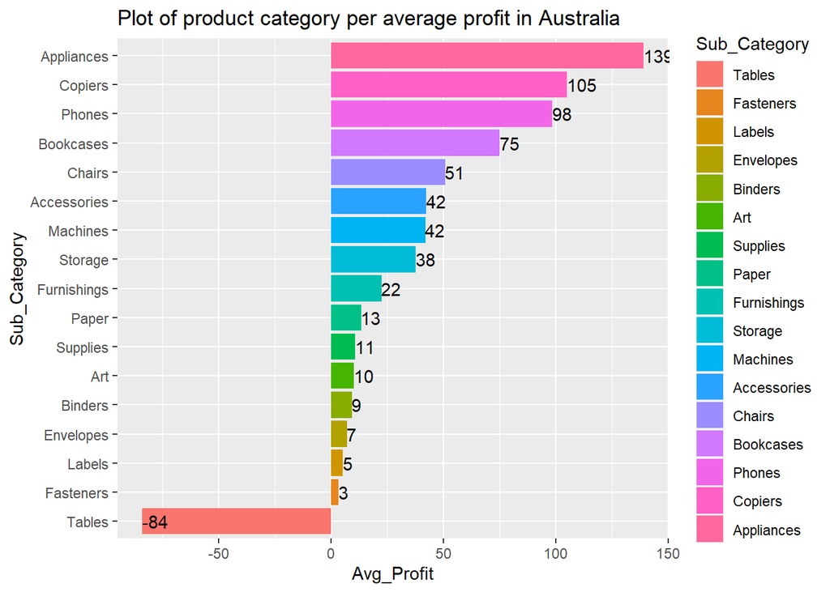

```r
Aust_sub$Sub_Category <- factor(Aust_sub$Sub_Category, levels = Aust_sub$Sub_Category[order(Aust_sub$Avg_Profit)])

ggplot(data = Aust_sub, aes( y = Sub_Category, x = Avg_Profit, fill = Sub_Category)) + geom_bar(stat ="identity")+ ggtitle(label = "Plot of product category per average profit in Australia")+
  geom_text(aes(label = round(Avg_Profit)),hjust = 0.01)
```

The product subcategory in Australia with the highest average profit is Appliances.

Question 7. a)Which customer returned items and what segment do they belong b)Who are the most valuable customers and what do they purchase?

```r
#extract segment, purchase, order_ID from orders table

mini_table <- orders %>% select(Segment,Order_ID,Customer_Name,Customer_ID,Product_Name, Quantity)

#A new table
customer_return <- left_join(returns,mini_table, by ='Order_ID')

customer_isonu <- customer_return %>% group_by(Customer_Name) %>% summarise(Segment,Quantity = sum(Quantity))
customer_isonu <- customer_isonu %>% distinct() %>% arrange(desc(Quantity))


#break it down by Segment
unique(customer_isonu$Segment)
```

```
## [1] "Consumer"    "Corporate"   "Home Office"
```

```r
customer_isonu_Consumer <- customer_isonu %>% filter(Segment == "Consumer")
customer_isonu_Consumer
```

| Customer_Name | Segment | Quantity |
| --- | --- | --- |
| Ted Butterfield | Consumer | 116 |
| Natalie Webber | Consumer | 74 |
| Gary Hwang | Consumer | 68 |
| Shahid Collister | Consumer | 68 |
| Mike Kennedy | Consumer | 67 |
| Lena Creighton | Consumer | 60 |
| Joe Elijah | Consumer | 57 |
| Susan Pistek | Consumer | 56 |
| Arthur Gainer | Consumer | 54 |
| Seth Vernon | Consumer | 52 |

[output cut: 309 more lines]

```r
customer_isonu_Corporate <- customer_isonu %>% filter(Segment == "Corporate")
customer_isonu_Corporate
```

| Customer_Name | Segment | Quantity |
| --- | --- | --- |
| Nat Gilpin | Corporate | 73 |
| Steven Ward | Corporate | 73 |
| Edward Hooks | Corporate | 63 |
| Anthony Johnson | Corporate | 61 |
| Bart Watters | Corporate | 61 |
| Ken Black | Corporate | 60 |
| Hilary Holden | Corporate | 59 |
| Tom Stivers | Corporate | 59 |
| Sally Hughsby | Corporate | 58 |
| Jennifer Patt | Corporate | 53 |

[output cut: 181 more lines]

```r
customer_isonu_HO <- customer_isonu %>% filter(Segment == "Home Office")
customer_isonu_HO
```

| Customer_Name | Segment | Quantity |
| --- | --- | --- |
| Valerie Takahito | Home Office | 53 |
| Mike Pelletier | Home Office | 50 |
| Mathew Reese | Home Office | 46 |
| Deanra Eno | Home Office | 45 |
| Eugene Hildebrand | Home Office | 44 |
| Adrian Hane | Home Office | 42 |
| Frank Merwin | Home Office | 38 |
| Emily Ducich | Home Office | 37 |
| Nathan Mautz | Home Office | 37 |
| Roger Barcio | Home Office | 36 |

[output cut: 99 more lines]

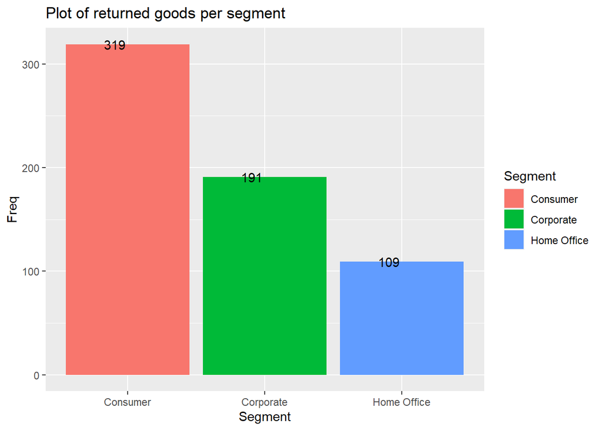

```r
#Lets visualize
 new_view <- customer_isonu %>% group_by(Segment) %>% summarise(Freq = n())

ggplot( data = new_view, aes(x= Segment, y = Freq, fill= Segment))+ geom_bar(stat="identity") + ggtitle(label = "Plot of returned goods per segment")+
  geom_text(aes(label = round(Freq)),hjust = 1.0999)
```

```r
customer_isonu_Consumer
```

| Customer_Name | Segment | Quantity |
| --- | --- | --- |
| Ted Butterfield | Consumer | 116 |
| Natalie Webber | Consumer | 74 |
| Gary Hwang | Consumer | 68 |
| Shahid Collister | Consumer | 68 |
| Mike Kennedy | Consumer | 67 |
| Lena Creighton | Consumer | 60 |
| Joe Elijah | Consumer | 57 |
| Susan Pistek | Consumer | 56 |
| Arthur Gainer | Consumer | 54 |
| Seth Vernon | Consumer | 52 |

[output cut: 309 more lines]

```r
customer_isonu_Corporate
```

| Customer_Name | Segment | Quantity |
| --- | --- | --- |
| Nat Gilpin | Corporate | 73 |
| Steven Ward | Corporate | 73 |
| Edward Hooks | Corporate | 63 |
| Anthony Johnson | Corporate | 61 |
| Bart Watters | Corporate | 61 |
| Ken Black | Corporate | 60 |
| Hilary Holden | Corporate | 59 |
| Tom Stivers | Corporate | 59 |
| Sally Hughsby | Corporate | 58 |
| Jennifer Patt | Corporate | 53 |

[output cut: 181 more lines]

```r
customer_isonu_HO
```

| Customer_Name | Segment | Quantity |
| --- | --- | --- |
| Valerie Takahito | Home Office | 53 |
| Mike Pelletier | Home Office | 50 |
| Mathew Reese | Home Office | 46 |
| Deanra Eno | Home Office | 45 |
| Eugene Hildebrand | Home Office | 44 |
| Adrian Hane | Home Office | 42 |
| Frank Merwin | Home Office | 38 |
| Emily Ducich | Home Office | 37 |
| Nathan Mautz | Home Office | 37 |
| Roger Barcio | Home Office | 36 |

[output cut: 99 more lines]

From the plot, consumer category has the largest number of returned goods, followed by corporate and then Home office.

question 7b Who are the most valuable customers and what do they purchase? MVP :-)

```r
MVP <- mini_table %>% group_by(Customer_ID) %>% summarise(Product_Name,Customer_Name, Quantity = sum(Quantity))
MVP <- MVP %>% as.data.frame( ) %>% arrange(desc(Quantity))

View(MVP)
```

```r
#lets visualize customers per quantity ordered
visualize_MVP <- MVP %>% select(-Product_Name) %>%distinct(Customer_Name, Quantity )
```

[figure not shown]